# Fitting Data

```python
import matplotlib.pyplot as plt
import numpy as np

from astropy.table import QTable
from astropy import units as u
from astropy import constants as const
from scipy.optimize import curve_fit
```

# Power on the Moon

[figure not shown]

- The Apollo lunar mission deployed a series of experiments on the Moon.
- The experiment package was called the Apollo Lunar Surface Experiments Package [(ALSEP)](https://en.wikipedia.org/wiki/Apollo_Lunar_Surface_Experiments_Package)
- The ALSEP was powered by a radioisotope thermoelectric generator [(RTG)](https://en.wikipedia.org/wiki/Radioisotope_thermoelectric_generator)
- An RTG is basically a fist-sized slug of Pu-238 wrapped in a material that generates electric power when heated.
- Since the RTG is powered by a radioisotope, the output power decreases over time as the radioisotope decays.

## Read in the datafile

The data file `https://uwashington-astro300.github.io/A300_Data/Apollo_RTG.csv` contains the power output of the Apollo 12 RTG as a function of time.

The data colunms are

- [Day] - Days on the Moon
- [Power] - RTG power output in Watts

Read in the datafile as a astropy `QTable`

```python
apollo_data = QTable.read('https://uwashington-astro300.github.io/A300_Data/Apollo_RTG.csv',
                       format='ascii.csv')
apollo_data.info()
```

```
<QTable length=46>
 name  dtype
----- -------
  Day float64
Power float64
```

Add units to the columns

```python
my_moon_days = apollo_data['Day'] * (u.day)
my_power_output = apollo_data['Power'] * (u.W)
```

## Plot the Data

- Day vs. Power
- Fit the function with a (degree = 3) polynomial
- Plot the fit with the data
- Output size w:11in, h:8.5in
- Make the plot look nice (including clear labels)

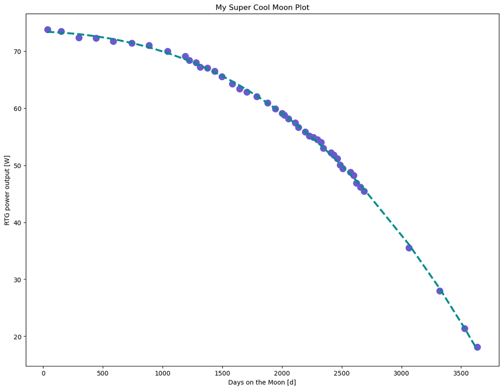

```python
fig, ax = plt.subplots(
    figsize = (11,8.5),
    constrained_layout = True)

ax.set_xlabel(f"Days on the Moon [{my_moon_days.unit}]")
ax.set_ylabel(f"RTG power output [{my_power_output.unit}]")
ax.set_title("My Super Cool Moon Plot")

ax.plot(my_moon_days, my_power_output,
        color = "slateblue",
        marker = "o",
        linestyle = "None",
        markersize = 10);
my_moon_years = my_moon_days.to(u.yr)

my_fit= np.polyfit(my_moon_days.to(u.yr).value, my_power_output.value, 3)

fitted_polynomial = np.poly1d(my_fit)

apollo_data['Fit'] = (fitted_polynomial(my_moon_days.to(u.yr).value)) * my_power_output.unit

ax.plot(my_moon_days, apollo_data['Fit'],
        marker = "None",
        linewidth = 3,
        color = "darkcyan",
        linestyle = '--',
        label = "Fit to Data")
```

## Power over time

- All of your answer should be formatted as sentences
- For example: `The power on day 0 is VALUE UNIT`
- Pay attention to the requested output units
- Do not pick the complex roots!

### 1 - What was the power output on Day 0?

```python
print(f"The power output on day 0 is {my_power_output[0]:.2f}.")
```

```
The power output on day 0 is 73.79 W.
```

### 2 - How many YEARS after landing could you still power a 60 W lightbulb?

```python
print(f"You could still power a 60 {my_power_output.unit} lightbulb up to {((fitted_polynomial - 60).roots[2]).real:.2f} {my_moon_years.unit} after landing.")
```

```
You could still power a 60 W lightbulb up to 5.31 yr after landing.
```

### 3 - How many YEARS after landing could you still power a 5 W USB device?

```python
print(f"You could still power a 5 {my_power_output.unit} USB device up to {((fitted_polynomial - 5).roots[2]).real:.2f} {my_moon_years.unit} after landing.")
```

```
You could still power a 5 W USB device up to 10.84 yr after landing.
```

### 4 - How many YEARS after landing until the power output is 0 W?

```python
print(f"The power output reaches 0 {my_power_output.unit} after {(fitted_polynomial.roots[2]).real:.2f} {my_moon_years.unit}")
```

```
The power output reaches 0 W after 11.16 yr
```

# Fitting data to a function

- The datafile `https://uwashington-astro300.github.io/A300_Data/linedata.csv` contains two columns of data [no units]

#### Read in the Data as an astropy `Qtable`

```python
linedata = QTable.read('https://uwashington-astro300.github.io/A300_Data/linedata.csv',
                       format='ascii.csv')
linedata.info()
```

```
<QTable length=101>
   name     dtype
---------- -------
wavelength float64
      flux float64
```

#### Plot the Data

- Output size w:11in, h:8.5in
- Make the plot look nice (including clear labels and a legend)

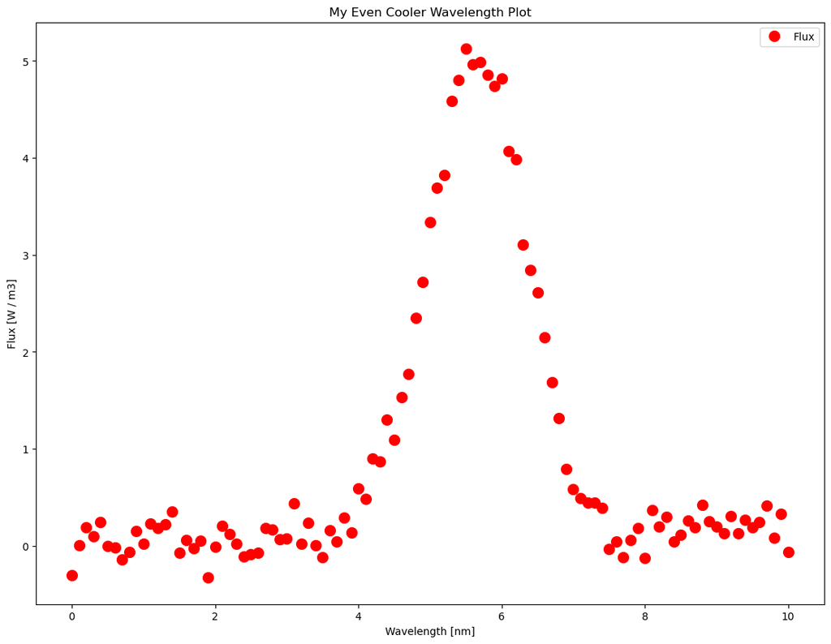

```python
wavelength = linedata['wavelength'] * (u.nm)
flux = linedata['flux'] * (u.W / u.m ** 3)

fix, ax = plt.subplots(
    figsize = (11,8.5),
    constrained_layout = True)

ax.set_xlabel(f"Wavelength [{wavelength.unit}]")
ax.set_ylabel(f"Flux [{flux.unit}]")
ax.set_title("My Even Cooler Wavelength Plot")

ax.plot(wavelength, flux,
        color = "red",
        marker = "o",
        linestyle = "None",
        markersize = 10,
        label = "Flux");

another_fit= np.polyfit(wavelength.value, flux.value, 3)

another_polynomial = np.poly1d(another_fit)

ax.legend(loc=0)
```

#### Fit a gaussian of the form:

$$ \huge f(x) = A e^{-\frac{(x - C)^2}{W}} $$

- A = amplitude of the gaussian
- C = x-value of the central peak of the gaussian
- W = width of the gaussian
- Find the values `(A,C,W)` that best fit the data

```python
from scipy.optimize import curve_fit

def gaussian(x, A, C, W):
    return A * np.exp(-((x - C) ** 2)/W)

A_guess = 5
C_guess = 5.6
W_guess = 1.2

init_guesses = [A_guess, C_guess, W_guess]

fitpars, error = curve_fit(gaussian,
                           wavelength.value,
                           flux.value,
                           p0 = init_guesses)

print(fitpars)

ax.legend(loc=0);
```

```
[5.07800572 5.65866099 0.97344419]
```

#### Plot the Data and the Fit on the same plot

- Output size w:11in, h:8.5in
- Make the plot look nice (including clear labels and a legend)

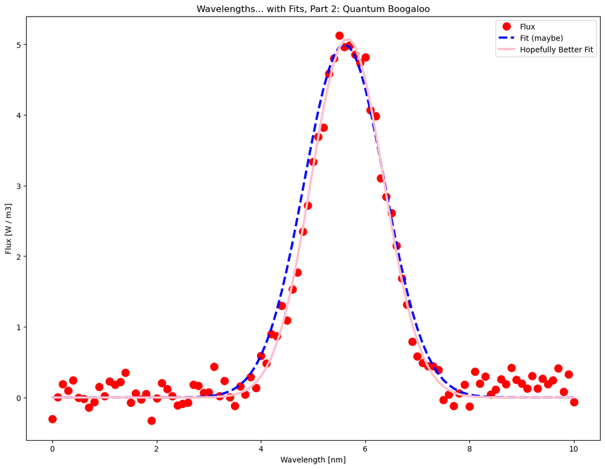

```python
wavelength = linedata['wavelength'] * (u.nm)
flux = linedata['flux'] * (u.W / u.m ** 3)

fix, ax = plt.subplots(
    figsize = (11,8.5),
    constrained_layout = True)

ax.set_xlabel(f"Wavelength [{wavelength.unit}]")
ax.set_ylabel(f"Flux [{flux.unit}]")
ax.set_title("Wavelengths... with Fits, Part 2: Quantum Boogaloo")

another_fit= np.polyfit(wavelength.value, flux.value, 3)

another_polynomial = np.poly1d(another_fit)

ax.plot(wavelength, flux,
        color = "red",
        marker = "o",
        linestyle = "None",
        markersize = 10,
        label = "Flux");

ax.plot(wavelength, gaussian(wavelength.value, *init_guesses),
        color = "blue",
        marker = "None",
        linestyle = "--",
        linewidth = 3,
        label = "Fit (maybe)")

ax.plot(wavelength, gaussian(wavelength.value, *fitpars),
        color = "pink",
        marker = "None",
        linestyle = "-",
        linewidth = 3,
        label = "Hopefully Better Fit")

ax.legend(loc=0);
```

### Due Wed Feb 11 - 1 pm

- `File -> Download as -> HTML (.html)`
- `upload your .html file to the class Canvas page`